# Exploratory Data Analysis

Questions, visual evidence, and the next question

## Warmup: what would you ask next?

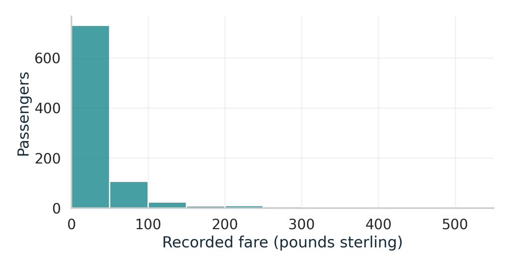

Histogram of recorded Titanic fares, with most observations in lower fare bins and a long right tail.

What do you notice?

What question would help you understand it?

Which view would you try next?

## A question guides the next view

**Question:** What do we want to understand?

**Evidence:** Which observations, variables, and comparison help?

**Interpretation:** What does the view show, and what remains unresolved?

**Follow-up:** What should we examine next?

## Titanic: a live investigation

How does survival vary by passenger class?

891 passenger records in this subset. One row represents one passenger.

Open **`titanic_live_scaffold.ipynb`** in Positron.

The investigation will move from survivor counts to survival proportions, then add recorded sex through color.

## Tornado data: what does one row mean?

**4,706 whole tornado tracks, 2015-2018**

| tornado_id | event_date | start_state | ef_rating | path_length_miles | max_width_yards |
| --- | --- | --- | --- | --- | --- |
| 2015-549199 | 2015-01-03 | MS | 0 | 0.08 | 50 |
| 2015-549208 | 2015-01-03 | MS | 1 | 1.88 | 50 |

These are the first two records, shown to explain the schema.

A track can cross state lines. It still occupies one row.

## The fields we can explore

| Information | Variables and meaning |
| --- | --- |
| Time | Start date, year, month, start hour in **CST** |
| Location | Starting state, start and end coordinates |
| Track size | Length in **miles**, maximum width in **yards** |
| Intensity | Ordered **EF rating**, sometimes missing |
| Outcomes | States affected, injuries, fatalities |

The identifier names a record. Its numeric-looking parts are not measurements.

## EF ratings and missing information

EF0 through EF5 are **ordered damage categories** associated with estimated winds.

EF0 is valid. An unknown rating is missing, not zero.

This snapshot has **111 unknown ratings**. Keep those records until your question requires a decision about them.

The file has no duration, narrative summary, city name, population, or exposed-area denominator.

## Round 1: question generation

**4 minutes with your original group**

Generate as many distinct questions as you can.

For each, identify the columns that could provide evidence.

The group with the most defensible distinct questions wins.

## Round 2: one question to investigate

**2 minutes with your original group**

Our question is …

We will examine these observations or groups …

We need these variables and units …

Our first plot or summary will help because …

For a rate, name the denominator.

## Round 3: your investigation

**18 minutes with your original group**

Open **`tornadoes_starter.ipynb`**.

Make a first visualization and describe what it shows.

Name something it leaves unresolved, then investigate further.

Keep your plot available for sharing. An inconclusive finding can still be useful.

## New groups: sharing investigations

**10 minutes with your new group**

Each person has about 2 minutes:

- What question did you investigate?
- What does your visualization show?
- How did your question or approach change?
- What would you investigate next?

Listeners: ask a useful follow-up question.

## What moved the investigation forward?

A visualization that changed a question

A question the available data could not fully answer

An approach you learned from someone else

One next question you would pursue

## Next class: passenger profiles

We compared Titanic passengers a few variables at a time.

How could we explore similarities across age, fare, family size, class, and embarkation together?

We will return to Titanic and add dimensionality reduction.

## Reference: survivor counts

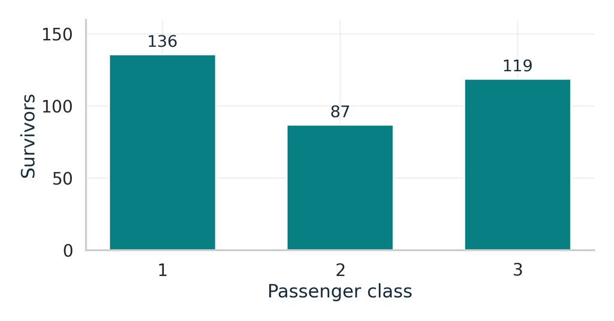

Bar chart of survivor counts by passenger class: 136, 87, and 119.

This answers how many survived. What denominator would let us compare proportions?

## Reference: survival proportions

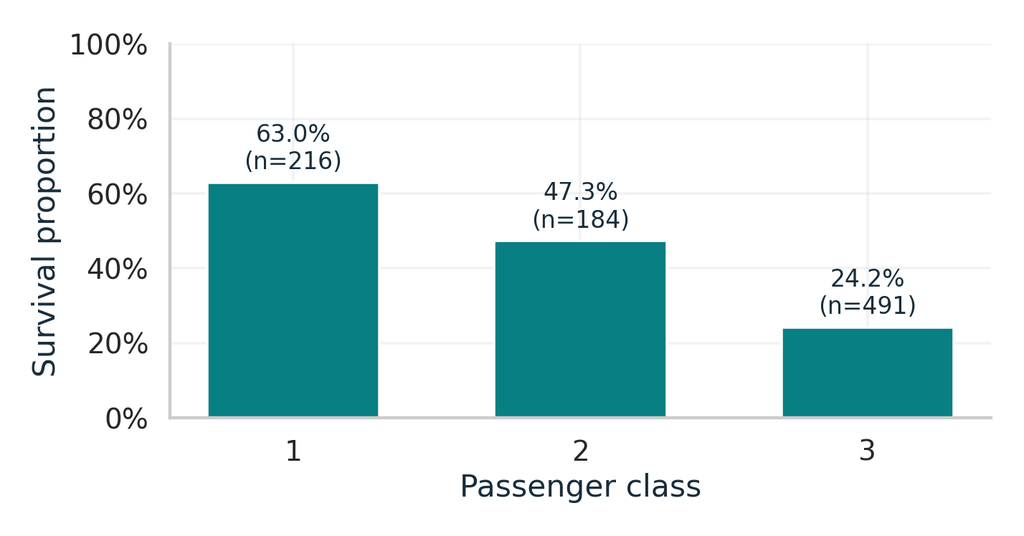

Survival proportions by class: 63.0%, 47.3%, and 24.2%, with denominators 216, 184, and 491.

Each denominator includes all passengers in that class in this subset.

## Reference: adding recorded sex

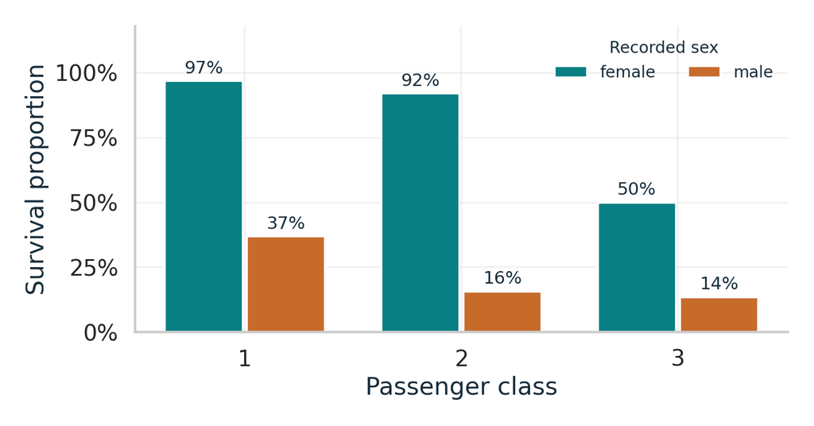

Grouped bar chart of survival proportions by passenger class and recorded sex.

The denominator now uses each class-by-sex group. These are descriptive associations.

## Sources

- [R for Data Science: EDA](https://r4ds.hadley.nz/EDA.html)
- [Seaborn Titanic data](https://github.com/mwaskom/seaborn-data)
- [NOAA SPC Severe Weather Database](https://www.spc.noaa.gov/wcm/#data)
- [National Weather Service: EF scale](https://www.weather.gov/oun/efscale)

The website’s data guide documents the snapshots, units, and preparation.